# BMEG310 - Assignment 3

## Introduction

*Epstein-Barr Virus (EBV) is a herpes virus and the cause of mononucleosis. Like other herpes viruses, infected cells can remain in a latent phase in the infected person their entire lives. B-cells are the usual target of EBV. When infected, B-cells can become immortalized, and can be cultured in vitro as Lymphoblastoid Cell Lines (LCLs). Like some other viruses, this immortalization can predispose the individual to certain types of cancer. For instance, Hodgkin’s Lymphoma is derived from EBV-infected B cells.*

*Today, we’re going to look at gene expression data to see how EBV infection changes the transcriptome. We will be looking at B-cell and LCL RNA-seq data from 5 donors, where LCLs were made from each of the donor’s B-cells. Please start from this file and add code/code blocks/and commentary as needed.*

## Load data

*Load needed libraries (install any you don’t yet have - edgeR can be installed through BioConductor)*

*Load data:*

```r
rnaSeqData =  read.table(textConnection(readLines(gzcon(url(
  "https://ftp.ncbi.nlm.nih.gov/geo/series/GSE126nnn/GSE126379/suppl/GSE126379_BLCL_processed.txt.gz")))),
  sep="\t", stringsAsFactors = FALSE, header = TRUE)
```

*Reshape and re-label data to make it more usable.*

```r
#melt the data frame so that there is one row for every gene-sample-quantification.type (see below) combination
rnaSeqDataMelted = melt(rnaSeqData, id.vars=c("Chromosome", "Gene.Name", "Gene.ID", "Sum.of.Exon.Length.of.Gene"))
#label every value as a read count, but...
rnaSeqDataMelted$quantification.type = "counts";
#relabel those that are really RPKM
rnaSeqDataMelted$quantification.type[grepl(rnaSeqDataMelted$variable,pattern = "RPKM")] = "RPKM";
#get the donor (human) ID
rnaSeqDataMelted$donor = gsub(".*BLCL_([ABCDE])([12]).*", "\\1", rnaSeqDataMelted$variable)
#Get the identifier they use to distinguish LCLs from B-cells
rnaSeqDataMelted$celltype = gsub(".*BLCL_([ABCDE])([12]).*", "\\2", rnaSeqDataMelted$variable)
#They didn't label the cell types clearly, so we're going to guess their assignment and verify below
rnaSeqDataMelted$celltype[rnaSeqDataMelted$celltype=="1"]="LCL"
rnaSeqDataMelted$celltype[rnaSeqDataMelted$celltype=="2"]="B"
#Remove this, since we have already parsed out the needed info
rnaSeqDataMelted$variable=NULL;
rnaSeqDataMelted$Gene.Name=NULL; #we only use Gene.ID
rnaSeqDataMelted$sampleID = paste(rnaSeqDataMelted$celltype, rnaSeqDataMelted$donor, sep="_")
#divide data into read counts and RPKM
rnaSeqDataMeltedCounts = rnaSeqDataMelted[rnaSeqDataMelted$quantification.type=="counts",]
rnaSeqDataMeltedRPKM = rnaSeqDataMelted[rnaSeqDataMelted$quantification.type=="RPKM",]
#relabel "value" as appropriate, and remove the 'quantification.type' column
rnaSeqDataMeltedCounts$counts=rnaSeqDataMeltedCounts$value;
rnaSeqDataMeltedCounts$value=NULL;
rnaSeqDataMeltedCounts$quantification.type=NULL;
rnaSeqDataMeltedRPKM$RPKM=rnaSeqDataMeltedRPKM$value;
rnaSeqDataMeltedRPKM$value=NULL;
rnaSeqDataMeltedRPKM$quantification.type=NULL;
rm('rnaSeqDataMelted') # remove
```

*Here, `rnaSeqDataMeltedRPKM` contains the gene expression “Reads per kilobase of transcript per million reads”, and `rnaSeqDataMeltedCounts` contains the raw count data.*

## Questions

### Question 1

*It is always important to perform Quality Control on your data.*

#### Question 1a

*For some reason, the authors labeled the different cell types “1” and “2” in this table. We need to figure out which is which. You know that EBV induces the NF-kappaB pathway, and that the TNF gene should be highly induced. Make a graph that shows the relative gene expression levels of TNF (y axis) for both cell types (x axis), for each donor (colour or “fill”).*

*Enter your answer below:*

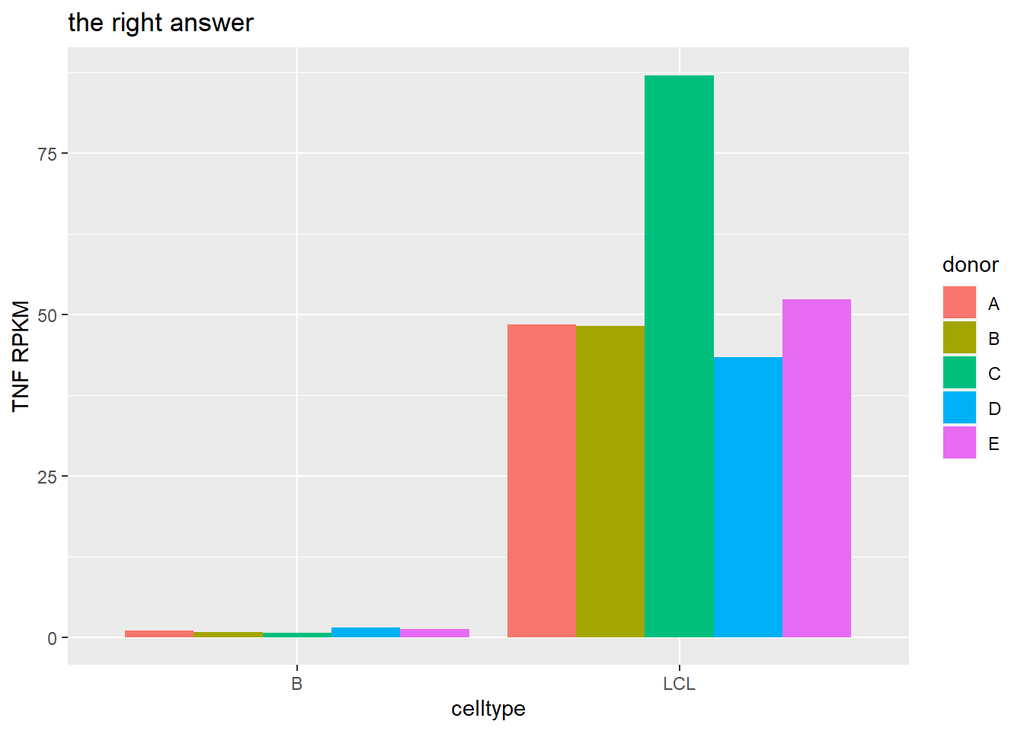

```r
p=ggplot(rnaSeqDataMeltedRPKM[rnaSeqDataMeltedRPKM$Gene.ID=="TNF", ], aes(x=celltype, y=RPKM, fill=donor))+geom_bar(stat="identity", position = "dodge")+ylab("TNF RPKM")+ggtitle("the right answer");print(p)
```

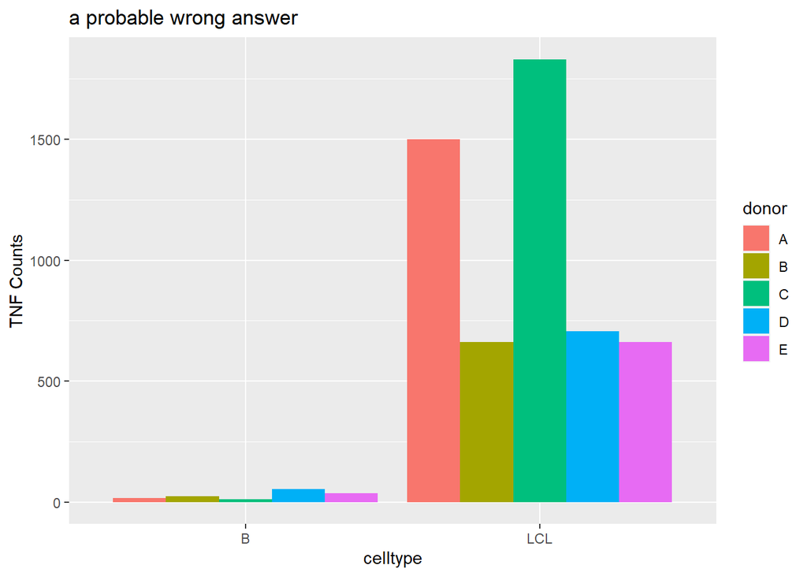

```r
p=ggplot(rnaSeqDataMeltedCounts[rnaSeqDataMeltedCounts$Gene.ID=="TNF", ], aes(x=celltype, y=counts, fill=donor))+geom_bar(stat="identity", position = "dodge")+ylab("TNF Counts")+ggtitle("a probable wrong answer");print(p)
```

*Explain what you see. Are the celltype labels correct?*

Answer: the celltype labels are correct. LCLs express TNF more than B cells.

*(1 mark for correct graph (RPKM or CPM, 0 if counts are used) + 1 for correct interpretation: yes they are correctly labeled /2)*

#### Question 1b

*With RNA-seq data, it is important both that samples have sufficient coverage, and that the samples have similar coverage. Either case can lead to underpowered analysis, or misleading results. Calcualte the read coverage for each sample. Make a plot with read coverage on the y-axis (total number of reads) and the samples on the x-axis.*

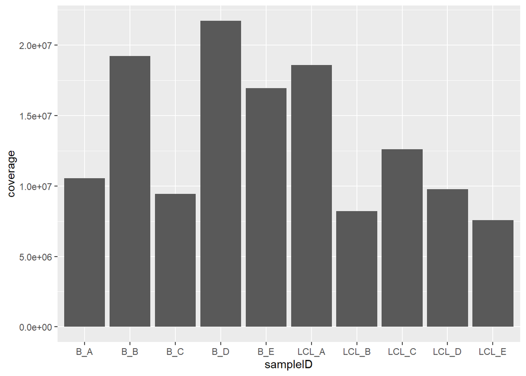

```r
readCoverage = cast(rnaSeqDataMeltedCounts, sampleID ~., value="counts", fun.aggregate = "sum")
names(readCoverage)[-1] = "coverage"
p=ggplot(readCoverage,aes(x=sampleID, y=coverage)) + geom_bar(stat="identity"); print(p)
```

*Which sample has the most coverage?*

```r
readCoverage$sampleID[readCoverage$coverage==max(readCoverage$coverage)]
```

```
## [1] "B_D"
```

*Which sample has the least?*

```r
readCoverage$sampleID[readCoverage$coverage==min(readCoverage$coverage)]
```

```
## [1] "LCL_E"
```

*What is the % difference between the max and min (relative to the min)?*

```r
100* max(readCoverage$coverage)/min(readCoverage$coverage)
```

```
## [1] 286.58
```

*(1 mark for correct graph of coverage + 0.5 marks for each follow up question /2.5)*

*In cases where samples have vastly different coverage, you can potentially down-sample the higher-coverage samples. Sometimes, throwing out the data in this way can also introduce new problems, so we’re going to stick with the data we have. What is more important in our analysis is that the LCLs and B-cells have similar coverage.*

#### Question 1c

*One easy way to compare the samples, is to calculate the pairwise correlation between them. In general, we do this in log gene expression space.*

*First we need to create a RPKM matrix. You can use the `reshape` package to change the shape of a `data.frame`. Below is an example for how to reshape our RPKM `data.frame` into a matrix of genes by samples.*

```r
# Here, we need fun.aggregate because there are duplicate gene names. We'll just add everything up for each gene name.
rpkmMatrix = cast(rnaSeqDataMeltedRPKM, Gene.ID ~ sampleID, value="RPKM", fun.aggregate="sum")
#now convert this to a matrix
row.names(rpkmMatrix) = rpkmMatrix$Gene.ID
rpkmMatrix$Gene.ID=NULL;
rpkmMatrix= as.matrix(rpkmMatrix)

head(rpkmMatrix)
```

```
##                      B_A         B_B        B_C         B_D         B_E
## 1/2-SBSRNA4 19.352915310 15.99571042 27.1820512 21.61277484 31.71742222
## A1BG         4.302521114  3.44955682  3.0061274  1.74767321  3.14328570
## A1BG-AS1     5.752198035  3.86229662  5.0845046  2.50873340  5.84991498
## A1CF         0.009967274  0.02185651  0.1225670  0.04834247  0.04338079
## A2LD1        1.537710375  1.66803075  1.1338164  1.20598716  1.11882550
## A2M          0.000000000  0.00000000  0.1140946  0.00000000  0.00000000
##                 LCL_A      LCL_B     LCL_C      LCL_D      LCL_E
## 1/2-SBSRNA4 4.2774210 2.67034568 3.5642703 4.27670517 6.07668480
## A1BG        2.7449356 7.44206031 8.7141524 6.54710043 9.28019191
## A1BG-AS1    3.1861872 3.65645724 6.5173728 2.78618307 7.57017987
## A1CF        0.0113048 0.01277064 0.0000000 0.02147553 0.01387007
## A2LD1       2.1522430 2.55707183 2.7325435 4.33530178 2.82273836
## A2M         8.3692316 0.20922668 0.3068694 0.30786211 0.02840488
```

*Calculate the pairwise Pearson correlations between samples. Use log(RPKM+1) to calculate the correlations. Plot the correlations as a heatmap.*

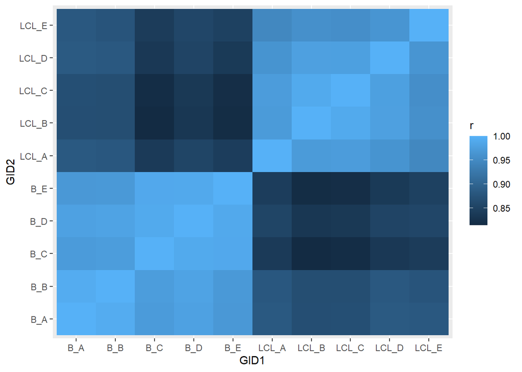

```r
pairwiseCorrels = cor(log(rpkmMatrix+1), method = "pearson")
pairwiseCorrelsMelted = as.data.frame(melt(pairwiseCorrels))
names(pairwiseCorrelsMelted) = c("GID1","GID2","r")
p=ggplot(pairwiseCorrelsMelted, aes(x=GID1, y=GID2, fill=r)) + geom_tile(); print(p)
```

*How similar are the B-cell samples to each other?*

Answer: B cells are very similar to each other for the most part.

*The LCLs to each other?*

Answer: LCLs are very similar to each other for the most part.

*The B-cells to the LCLs?*

Answer: B cells are not very similar to LCLs

*The donors are labeled [A-E]. What would we expect to see if there were donor-specific effects here (e.g. some donor-specific signal affecting both cell types)? Do we see them?*

Answer: If there were donor specific effects, we would expect the LCLs and B cells for donor A to be more similar than either are to the other samples (B-E), (same for donor B, etc.) This would be manifest as a diagonal line in the upper left and lower right quadrants of this plot. We don’t really see this. Certainly nothing striking.

*(1 mark for making correlation matrix correctly, 1 mark for correct graph, 0.5 marks for the first three follow up questions, 1 mark for the final one (0.5 for each of the two parts) /4.5)*

#### Question 1d

*Plot the kernel density estimate for RPKM (x axis). Describe the distribution.*

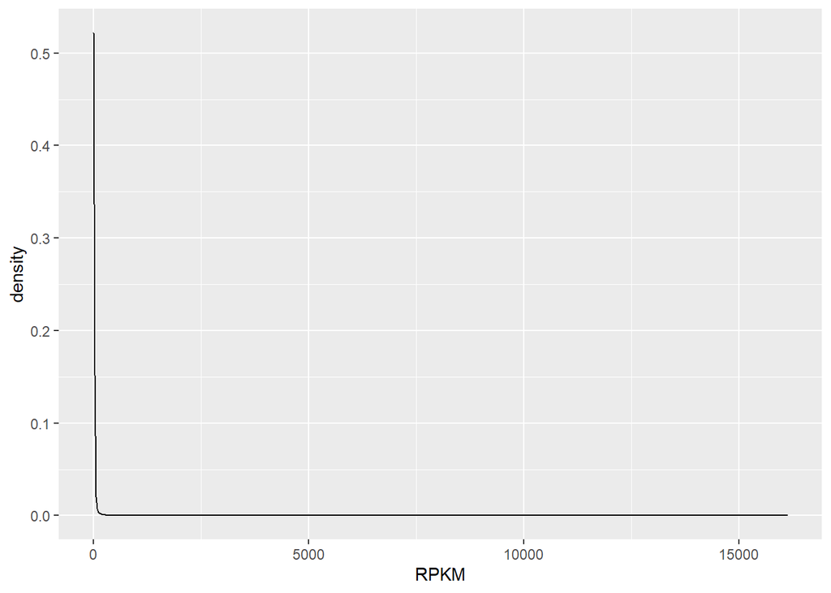

```r
p=ggplot(rnaSeqDataMeltedRPKM, aes(x=RPKM)) + geom_density(); print(p)
```

Answer: Most of the genes have a very low RPKM value and very few have extreme values. This is because on the scale of 1…15000, most genes are approximately 0.

*Plot the kernel density estimate for log(RPKM+1) (x axis). Describe the distribution.*

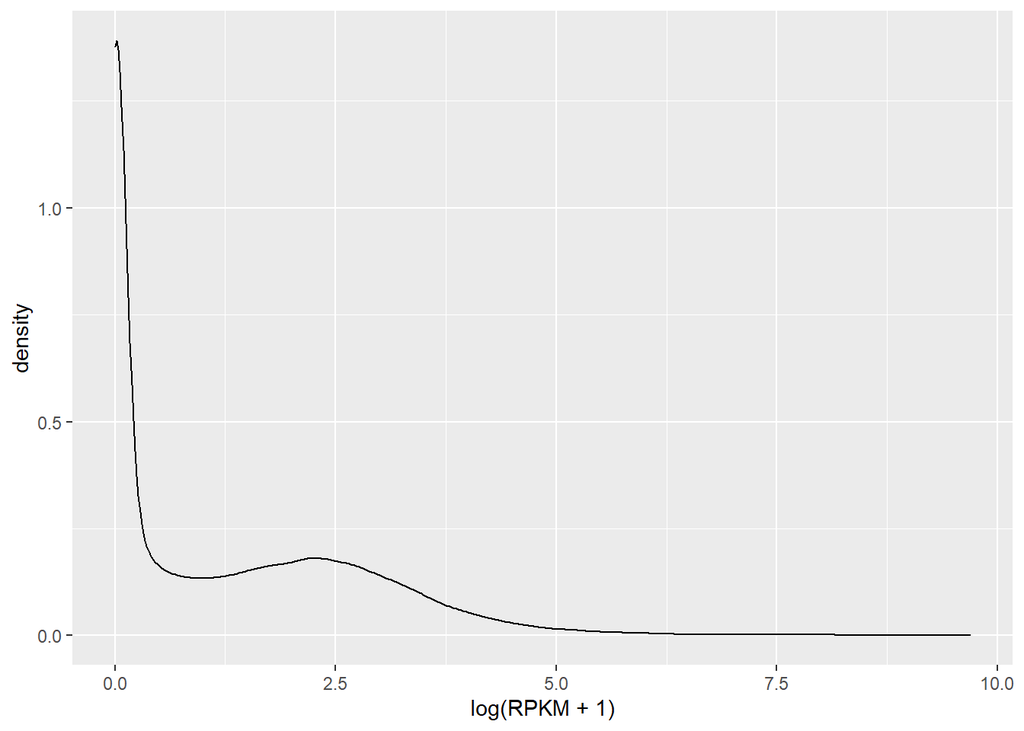

```r
p=ggplot(rnaSeqDataMeltedRPKM, aes(x=log(RPKM+1))) + geom_density(); print(p)
```

Answer: now that we have log-transformed it, we can see that while there are some outlier genes, most are approximately log-normally distributed about RPKM = e^2.5 = 12. There are still a large number of genes with RPKM equal to 0 (or close to).

*Why do we log-transform gene expression data?*

Answer: because the expression levels span such a high range that most values get squished near 0 if we don’t log transform. Another reason is because log transformation makes the values more like a normal distribution.

*Why do we use RPKM+1?*

Answer: if we didn’t add 1 to the RPKM, we would get many NAs since log(0) is undefined. (A reason to use 1, is because the scale of gene expression data for bulk samples is usually on the order of single digit millions of reads per sample, but you don’t need to note this for full marks).

*(1 for RPKM KDE + 0.5 for description, 1 for log(RPKM+1) KDE + 0.5 for description, 0.5 for two follow up questions /4)*

#### Question 1e

*It is common to exclude some genes from analysis. For instance, if the gene is not expressed, there is no way it can be differentially expressed. Even in cases where there are a few reads, it is common to exclude these genes too since there we cannot be confident in any differential expression based on very few reads. Calculate the mean number of reads per gene using the count data. We’re going to use a cutoff of a mean of at least 5 reads per gene, on average, to be included in the subsequent analysis. Plot the mean reads per gene as a Cumulative Distribution (see https://en.wikipedia.org/wiki/Cumulative_distribution_function), and indicate with a vertical line where the cutoff lies.*

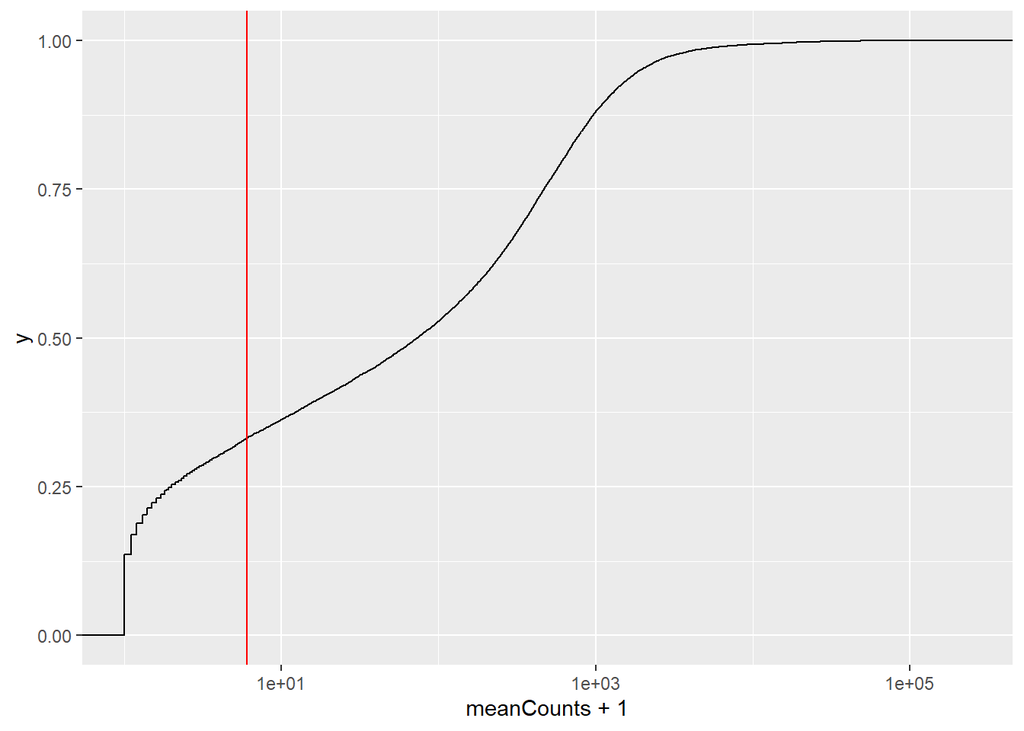

```r
meanReadsPerGene = cast(rnaSeqDataMeltedCounts, Gene.ID ~., value="counts", fun.aggregate = "mean")
names(meanReadsPerGene)[-1] = "meanCounts";
p=ggplot(meanReadsPerGene, aes(x=meanCounts+1)) + stat_ecdf()+scale_x_log10() + geom_vline(xintercept = 5+1, colour="red"); print(p)
```

*By looking at the graph, what fraction of genes will be excluded if we require an average of at least 5 reads per sample?*

Answer: about 32%

*(1 for CDF with cutoff indicated + 0.5 if log scale, 0.5 if answer is 32%+/-5% /2)*

#### Question 1f

*Make a vector of `Gene.ID`s for all the genes we will *include* in our analysis (e.g. those with 5 or more reads per sample on average). Name it `keepGenes`.*

```r
keepGenes = meanReadsPerGene$Gene.ID[meanReadsPerGene$meanCounts>=5];
```

*How many genes have we retained?*

```r
length(keepGenes)
```

```
## [1] 15533
```

*(1 mark for making keepGenes, 1 mark for correctly outputting length /2)*

#### Question 1f (bonus)

*`rnaSeqDataMeltedCounts` contains a commmon error introduced by pasting the data having passed through excel. Can you identify this error and show some examples?*

```r
meanReadsPerGene[grepl("Mar",meanReadsPerGene$Gene.ID),]
```

```
##       Gene.ID meanCounts
## 11635  Mar-01     2787.5
## 11636  Mar-02      387.9
## 11637  Mar-03      206.4
## 11638  Mar-04        0.2
## 11639  Mar-05      355.6
## 11640  Mar-06     2190.3
## 11641  Mar-07     1235.3
## 11642  Mar-08      410.9
## 11643  Mar-09      587.4
## 11644  Mar-10        0.9
## 11645  Mar-11        0.0
```

*(1 mark for showing the examples, 1 mark for indicating where it originated (date recognition by excel) /2)*

### Question 2

*We want to know what genes are differentially expressed between LCLs and B cells.*

*Today, we’re going to use edgeR. The user guide is here:* https://www.bioconductor.org/packages/release/bioc/vignettes/edgeR/inst/doc/edgeRUsersGuide.pdf

#### Question 2a

*For calculating differential expression, we need a count matrix. There is a lot more information in counts than in normalized counts. For example, you can believe 1/1E6 reads a lot less than 100/1E8 reads, but they both have the same RPKM values. Accordingly, Please create a matrix of counts (genes in the rows and samples in the columns) and filter it for genes with an average CPM>5.*

```r
# First we create a matrix of counts:
# Here, we need fun.aggregate because there are duplicate gene names. We'll just add everything up for each gene name.
countMatrix = cast(rnaSeqDataMeltedCounts[rnaSeqDataMeltedCounts$Gene.ID %in% keepGenes,], Gene.ID ~ sampleID, value="counts", fun.aggregate="sum")
#now convert this to a matrix
row.names(countMatrix) = countMatrix$Gene.ID
countMatrix$Gene.ID=NULL;
countMatrix= as.matrix(countMatrix)

head(countMatrix)
```

```
##             B_A B_B B_C B_D B_E LCL_A LCL_B LCL_C LCL_D LCL_E
## 1/2-SBSRNA4 195 294 245 449 514    76    21    43    40    44
## A1BG         80 117  50  67  94    90   108   194   113   124
## A1BG-AS1    129 158 102 116 211   126    64   175    58   122
## A2LD1        47  93  31  76  55   116    61   100   123    62
## A2M           0   0   5   0   0   723     8    18    14     1
## A2ML1        64  91 104 197 148    23     5     7    14    15
```

*Note in marking: question was originally confusing in its wording, so filtering by keepGenes (mean counts per sample) or mean CPM per sample are both acceptable here.*

*(2 marks for correctly creating (1) and filtering (1) matrix of counts /2)*

#### Question 2b

*EdgeR is exceptionally versatile, with many different options for analysis. Today, you’re going to use the GLM-quasi-likelihood approach to calculate differential expression. Below is some incomplete code that you can use to start with. Please complete the code so that edgeR uses your countMatrix to calculate differential expression comparing B cells to LCLs. Please also comment the code so that it is clear what each step does (in your own words).*

```r
ct = as.factor(gsub("([A-Z]*)_([A-E])","\\1",colnames(countMatrix)))
y = DGEList(counts=countMatrix, group=ct)
y = calcNormFactors(y)
design = model.matrix(~ct)
y = estimateDisp(y, design)
fit = glmQLFit(y, design)
qlf = glmQLFTest(fit, coef=2)

allDEStats = as.data.frame(topTags(qlf,n=nrow(countMatrix)))
allDEStats$Gene.ID=row.names(allDEStats)
head(allDEStats)
```

```
##               logFC   logCPM         F       PValue          FDR  Gene.ID
## CABLES1    7.284810 4.871271 1096.9879 1.309939e-13 2.034728e-09  CABLES1
## COBLL1   -11.563262 6.124874  924.0189 3.803525e-13 2.954008e-09   COBLL1
## GYLTL1B   -7.992116 5.252918  717.7910 1.818422e-12 7.770164e-09  GYLTL1B
## ARHGAP25  -4.345151 6.446624  684.6357 2.435841e-12 7.770164e-09 ARHGAP25
## Mar-01    -5.328861 7.403672  660.2506 3.047478e-12 7.770164e-09   Mar-01
## RASGRP2   -7.513219 7.986667  647.8032 3.427469e-12 7.770164e-09  RASGRP2
```

*(2 marks for the correct analysis, 2 marks for the correct and thorough documentation /4)*

#### Question 2c

*Now, let’s confirm that we did the comparison in the correct direction. We want to ensure that we did LCLs/B-cells, and not the other way around. Make a volcano plot using ggplot2 for this analysis. A volcano plot is a scatter plot with log(fold-change) on the x-axis, and -log(P-value) on the y-axis. Label TNF in this plot. Alter the above code if logFC is not expressed as log(LCLs/B-cells).*

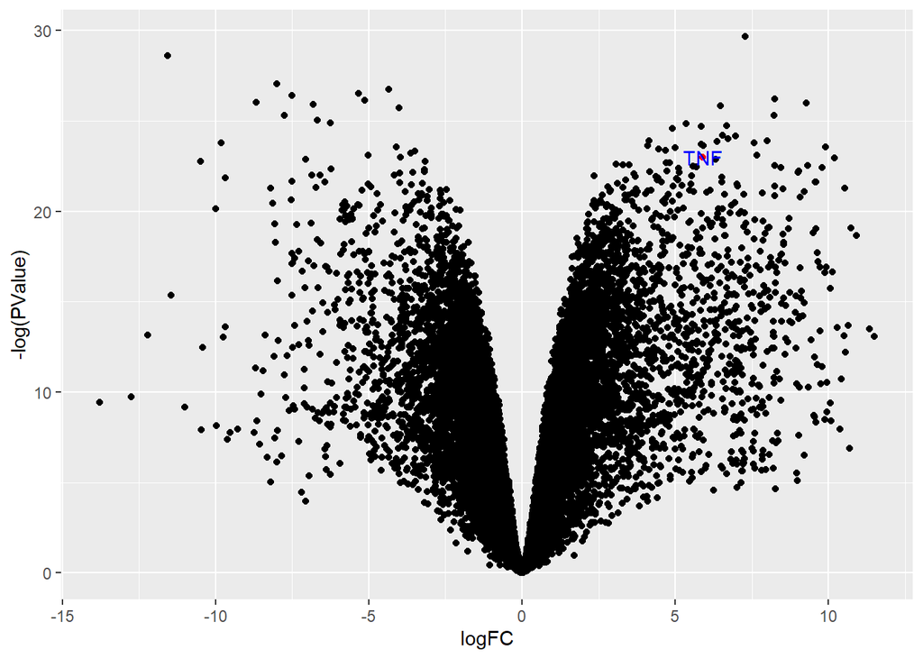

```r
p=ggplot(allDEStats, aes(x=logFC, y=-log(PValue),label=Gene.ID))+geom_point() +geom_point(data=allDEStats["TNF",], colour="red") +  geom_text(data=allDEStats["TNF",], colour="blue"); print(p);
```

*(1 mark for correct plot, 1 mark for labeling TNF [0 marks if TNF is not on theright hand side] /2)*

#### Question 2d

*In the case of this experiment, each donor had corresponding B cell and LCL samples - these are indicated by the ‘donor’ variable, which takes the values A-E. For instance, the LCLs and B-cells labeled with Donor ‘E’ are both from the same individual. What happens if there are person-specific differences in expression? For instance, what if person E had autoimmune disease? This could perturb both their B-cells and their resulting LCLs. These are called ‘paired samples’ since there is a pair of samples for each donor (B cells and LCLs). Repeat the analysis above, this time incorporating the knowledge of paired samples in the analysis, using the donor as a blocking variable.*

```r
ct = as.factor(gsub("([A-Z]*)_([A-E])","\\1",colnames(countMatrix)))
donors = as.factor(gsub("([A-Z]*)_([A-E])","\\2",colnames(countMatrix)))
yPaired = DGEList(counts=countMatrix, group=ct)
yPaired = calcNormFactors(yPaired)
designPaired = model.matrix(~ct + donors) # if this were ~ donors + ct, coef would have to change below
yPaired = estimateDisp(yPaired, designPaired)
fitPaired = glmQLFit(yPaired, designPaired)
qlfPaired = glmQLFTest(fitPaired, coef=2)

allDEStatsPaired = as.data.frame(topTags(qlfPaired,n=nrow(countMatrix)))
allDEStatsPaired$Gene.ID=row.names(allDEStatsPaired)
head(allDEStatsPaired)
```

```
##              logFC   logCPM        F       PValue          FDR Gene.ID
## TNFRSF8   9.344470 6.132205 895.3630 1.337444e-11 9.383793e-08 TNFRSF8
## AHRR      8.058063 5.614576 790.1304 2.578285e-11 9.383793e-08    AHRR
## EML6     -8.730322 5.449152 776.9646 2.815840e-11 9.383793e-08    EML6
## COBLL1  -11.575643 6.125704 737.2839 3.706561e-11 9.383793e-08  COBLL1
## ZC3H12C   8.247791 5.229653 711.0446 4.481636e-11 9.383793e-08 ZC3H12C
## CABLES1   7.301118 4.869331 710.8944 4.486599e-11 9.383793e-08 CABLES1
```

*(2 marks for correct analysis /2)*

### Question 3

*When performing any bioinformatic analysis, it is critically important to verify your answers. Here, we’re going to compare the results from our paired analysis vs. the unpaired analysis to ensure that our analysis is correct (go back and redo the previous parts if you find that your analysis appears to be incorrect).*

#### Question 3a

*Compare the results from the paired analysis vs. the original analysis (where donor was not considered).* *How many genes have a logFC that differs by 1 or more?*

```r
allDEStatsBoth = merge(allDEStats, allDEStatsPaired, suffixes=c('.unpaired','.paired'), by="Gene.ID")
allDEStatsBoth$logFC.difference = allDEStatsBoth$logFC.unpaired - allDEStatsBoth$logFC.paired;
sum(abs(allDEStatsBoth$logFC.difference)>1)
```

```
## [1] 86
```

*(1 mark correct code; if answer differs from 86, that could result from bugs in earlier code or using mean CPM instead of mean counts and are not penalized here /1)*

#### Question 3b

*Plot the logFC values for paired (x-axis) vs unpaired (y-axis) analyses. What is the Pearson r between the two?*

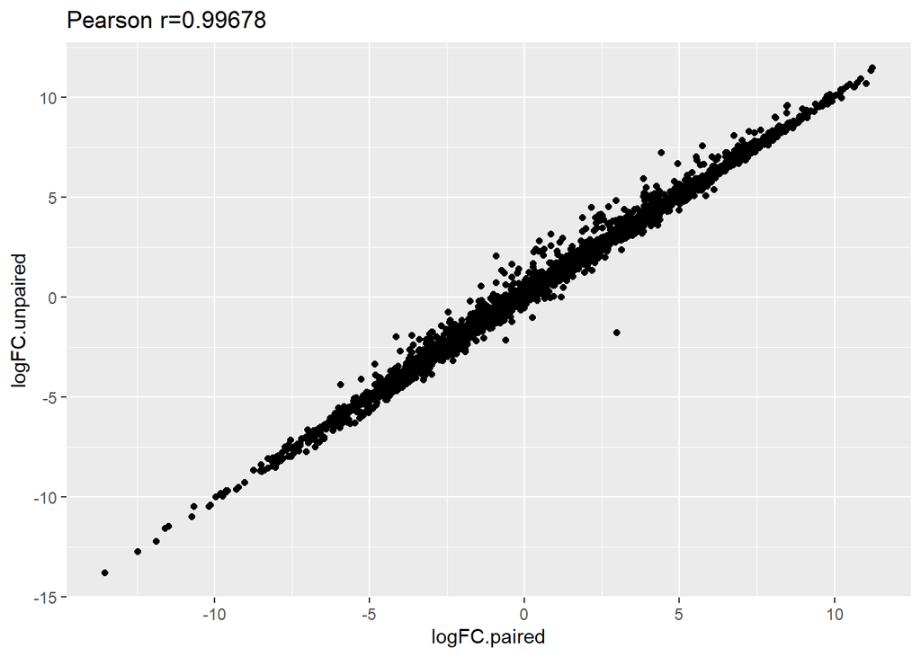

```r
p=ggplot(allDEStatsBoth, aes(x=logFC.paired, y=logFC.unpaired))+geom_point() + ggtitle(sprintf("Pearson r=%g", cor(allDEStatsBoth$logFC.paired, allDEStatsBoth$logFC.unpaired, method = "pearson"))); print(p);
```

*(3 marks: 1 for correct code to plot the two logFC values, 1 for correctly calculating the Pearson r, 1 mark for having the correct comparison (e.g. if one or both of the logFCs are wrong for this analysis because of an earlier bug, this analysis should have led you to notice and fix the earlier bug (e.g. if they are uncorrelated)) /3)*

#### Question 3c

*Why are there some genes whose logFC estimates differ so much between the paired and unpaired analyses? Let’s inspect the genes with a logFC difference between paired and unpaired of at least 1. A heatmap can be used to display a matrix of values. In this case, we want the values to represent log(RPKM+1) values (use `rnaSeqDataMeltedRPKM`), with genes (only those whose logFCs differ between the analysis using donor as a blocking variable vs. without by more than 1) on the y axis and samples on the x axis.*

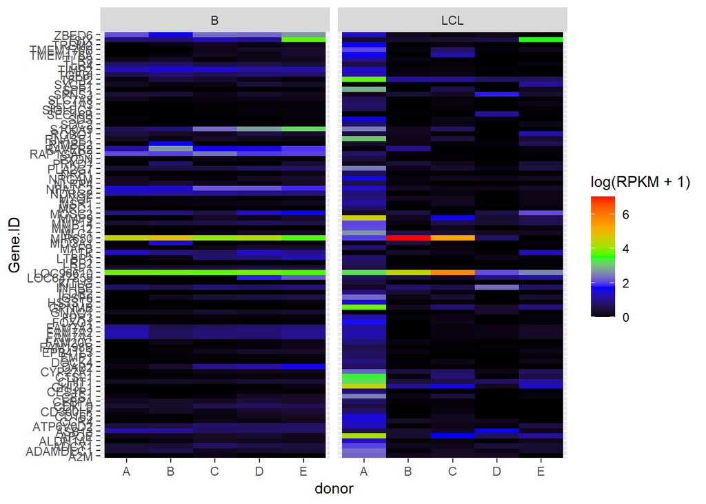

```r
p=ggplot(rnaSeqDataMeltedRPKM[rnaSeqDataMeltedRPKM$Gene.ID %in% allDEStatsBoth$Gene.ID[abs(allDEStatsBoth$logFC.difference)>1],], aes(x=donor, y=Gene.ID, fill=log(RPKM+1)))+geom_tile() + facet_grid(.~celltype, scales="free")+scale_fill_gradientn(colours = c("black","blue","green","orange","red"));print(p)
```

*What are some reasons why paired and unpaired analyses appear to be giving different answers in this case? Are there donor-specific things going on?*

Answer: If there were lots of donor-specific gene expression changes affecting the analysis, we would expect that some differences between the two analysis types result from donor-specific gene expression differences. While we do see some of these (e.g. donor E, second gene from the top), this does not appear to be true in the majority of cases.

*(1 mark for correctly producing heatmap (regardless of earlier bugs); 1 mark for reasonable interpretation. /2)*

### Question 4

*There are many different ways of normalizing RNA seq data and they all make different assumptions.*

*For more information on RNA-seq normalization methods, see this great post by Harold Pimentel: https://haroldpimentel.wordpress.com/2014/05/08/what-the-fpkm-a-review-rna-seq-expression-units/*

#### *From now on, we will be using only the paired (donor as blocking variable) analysis*

#### Question 4a

*edgeR uses TMM normalization. TMM normalization is usually a solid approach, but it assumes that most of the genes do not differ in expression between your samples. One approach you could use to check this is by looking at the P-value distribution from our DE analysis. For a well-behaved statistical test, P-values are uniformly distributed between 0 and 1. Plot the Cumulative Distribution of P-values for the paired analysis. On the same plot, include a CDF for 100,000 uniformly sampled random values between 0 and 1.*

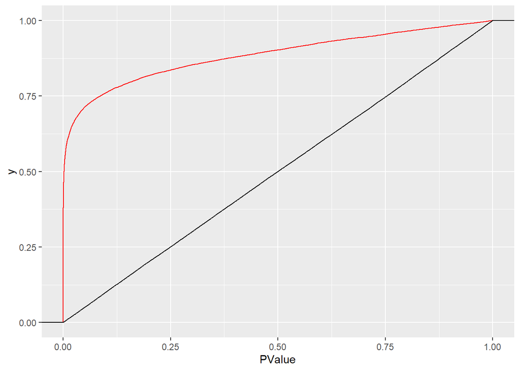

```r
p=ggplot() + stat_ecdf(data=allDEStatsPaired, aes(x=PValue), colour="red") + stat_ecdf(data=data.frame(x=runif(100000)), aes(x=x)); print(p)
```

*Do the P-values calculated by edgeR look like they are sampled uniformly between 0 and 1?*

Answer: not even close.

*Estimate the fraction of genes that appear to have differential expression (does not have to be exact):*

Answer: The 20% or so of highest P-values from the DE analysis appears to be approximately uniform, so probably these 20% represent non-DE genes. The bottom 50% of p-values look highly skewed to significance, so any answer between about 40%-90% is reasonable here.

*Do you think we should use TMM normalization for these samples? Why or why not?*

Answer: TMM assumes that most genes are not changing in their expression. Since that appears to not be true here, we should either use some other normalization method, or adjust the parameters so that more genes are trimmed before scaling samples.

*(1 mark for correct CDF for DE P-values, 1 for correct CDF of uniform values, 0.5 for each follow up question /3.5)*

#### Question 4b

*Another way to ensure that P-values are well-behaved is to make a Q-Q plot. A Q-Q plot, in this case, will show the expected P-values (under the null hypothesis) on the x axis, and actual p-values on the y-axis. Recall that by the definition of a P-value, if you generate `n` p-values under the null hypothesis, you expect to see a p-value of 1/`n` once in `n` null p-values. Meanwhile, all null p-values are approximately uniform between 1 and 1/`n`. Here, `n` is the number of DE tests you performed. Use -log(P) for both axes (this puts the most significant in the upper right, and least significant in the lower left). Also include the line y=x in red for comparison. For a well-behaved statistical test, most of the points should lie along the y=x line.*

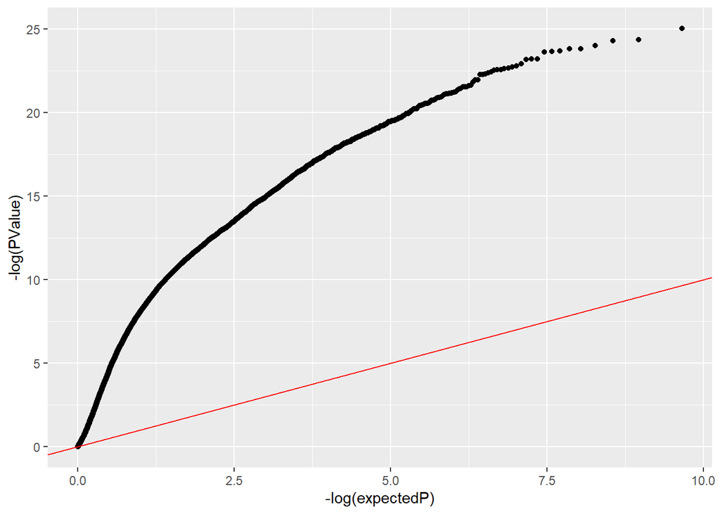

```r
allDEStatsPaired = allDEStatsPaired[order(allDEStatsPaired$PValue),]
allDEStatsPaired$expectedP = (1:nrow(allDEStatsPaired))/nrow(allDEStatsPaired)
#the following is also acceptable as it generates uniform random p-values and aligns them
#allDEStatsPaired$expectedP = sort(runif(nrow(allDEStatsPaired)))
p=ggplot(allDEStatsPaired, aes(x=-log(expectedP), y=-log(PValue)))+geom_point()+geom_abline(intercept = 0, slope = 1, colour="red"); print(p)
```

*Do most of the P-values lie along the y=x line?*

Answer: No. Few are on the line.

*What does this mean about how we did our analysis? What would you do differently if we were to redo the analysis?*

Answer: It probably means that the analysis can’t be trusted. One possible thing to do differently is to adjust the TMM normalization parameters and to pay more attention to whether the parameters we are using are reasonable (e.g. by making MA plots and seeing how many genes look like they are changing). Any reasonable answer for what to change when redoing is fine here.

*(2 marks for plot; 0.5 marks follow up 1, 1 mark for 2-part follow up 2 /3.5)*

#### Question 4c

*FDRs are automatically calculated by edgeR. plot the -log10(FDR) (y axis) versus the -log10(P-value) (x axis) for the paired DE analysis. Include the line y=x in red again for reference*

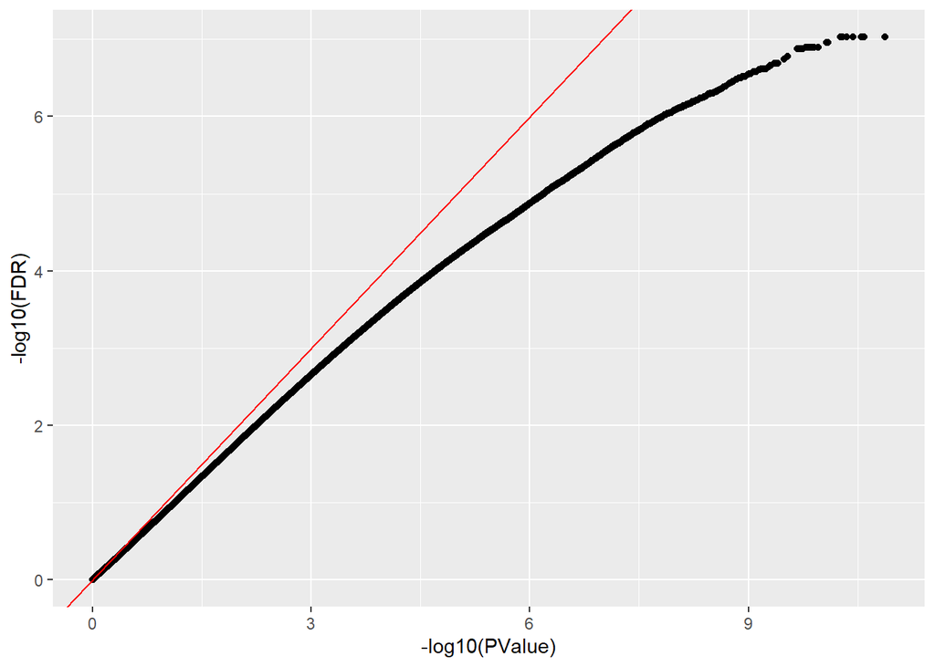

```r
p=ggplot(allDEStatsPaired, aes(x=-log10(PValue), y=-log10(FDR))) + geom_point()+geom_abline(intercept = 0, slope=1, colour="red"); print(p)
```

*Are the points above or below the line? Why?*

*(2 marks for correct graph, 1 mark for follow up question (0.5/part) /3)*

#### Question 4d

*If we took our set of significant DE genes to be those that meet an FDR of 1%, how many genes would be considered significantly DE?*

```r
sum(allDEStatsPaired$FDR<=0.01)
```

```
## [1] 8773
```

*What is the P-value of the gene with the highest FDR that is still less than or equal to FDR<1%?*

```r
allDEStatsPaired[allDEStatsPaired$FDR==max(allDEStatsPaired$FDR[allDEStatsPaired$FDR<=0.01]),]
```

```
##               logFC   logCPM        F      PValue         FDR   Gene.ID
## LOC220729 -1.090244 3.974852 11.94364 0.005647861 0.009999797 LOC220729
##           expectedP
## LOC220729 0.5647975
```

*Ignoring any potential flaws in the analysis up to this point and assuming our P-values and FDRs are well founded, is the probability of this gene NOT being differentially expressed greater or less than this P-value?*

Answer: Higher. This is because the raw P-value is not corrected for MHT and we expect low P-values by chance.

*Is the probability of this gene NOT being differentially expressed greater or less than this 1%?*

Answer: Higher. This is because the overall FDR when including this gene is 1%, but the genes with really low P-values are unlikely to be the false discoveries. This gene, with the least significant P-value is actually most likely to be the false discovery out of any genes included, and so the probability of it not being DE is greater than 1%.

*Note in marking: there was a correction issued to this question, where the question was unanswerable before the correction* *(1 mark for correctly getting the number of DE genes (although numbers may vary), 1 mark for correctly retreiving highest FDR gene with FDR<0.01, 0.5 marks for each follow up question /3)*

### Question 5

*Now we’re going to spend some time actually looking at the results of our analysis, trying to determine what is going on when B-cells are converted to LCLs.*

#### Question 5a

*GOrilla, which we use below, can take a single ranked list as input. Here, you should make two ranked lists of gene IDs, one with the gene IDs sorted by log FC from high to low, and the other from low to high. Use the paired analysis for this question. You will only want gene IDs written to the file (e.g. no row or column names, no quotes) - GOrilla will give error messages if it is not properly formatted.*

```r
write.table(x=allDEStatsPaired$Gene.ID[order(allDEStatsPaired$logFC)], file="20200930_high-low_in_B.txt", quote=F, row.names=F, col.names=F)
write.table(x=allDEStatsPaired$Gene.ID[order(-allDEStatsPaired$logFC)], file="20200930_high-low_in_LCL.txt", quote=F, row.names=F, col.names=F)
```

*(two marks for correctly outputting genes to files /2)*

#### Question 5b

*Now use GOrilla to measure gene set enrichment analysis for both sets of genes.* http://cbl-gorilla.cs.technion.ac.il/

*Use Homo sapiens; a single ranked list of genes (those we just created - run it twice, once per file); and all ontologies.*

*When inspecting the results, consider both the significance of the enrichment, the degree of enrichment, and the number of genes involved. For instance, a high-fold enrichment for a very specific term can give more insight than a more significant but lower fold enrichment for a more generic term. Alternatively, enrichments involving fewer genes are more likely to occur by chance, and so may have a high fold enrichment, but nonetheless be spurious.*

*What processes are relatively high in B cells?*

Answers: (some noted here) GPCRs, cell-cell adhesion, platelet activation, ion channels (e.g. calcium, sodium), plasma membrane

*Which are relatively high in LCLs?*

Answers: (some) chemotaxis, cytokine/chemokine, extracellular things

*What do you think could be happening as B-cells are reprogrammed to LCLs?*

Answer: any plausible answer will do here. This can be based entirely off of the GO analysis and does not require further research. E.g. LCLs appear to have had their ability to detect extracellular stimuli reprogrammed (GPCRs, cytokines, ion channels, plasma membrane), and LCLs might be more motile since B cells have more adherance genes (cell-cell adhesion in B, chemotaxis in LCLs).

*(2 marks each for noting GO terms in B cells and LCLs, 2 marks for plausible interpretation of GO terms /6)*